```python
from IPython.display import display
from IPython.display import HTML
import IPython.core.display as dpl
# hide code by default in HTML
dpl.display_html('<script>jQuery(function() {if (jQuery("body.notebook_app").length == 0) { jQuery(".input_area").toggle(); jQuery(".prompt").toggle();}});</script>', raw=True)

# add a button to toggle visibility of code blocks in HTML
dpl.display_html('''<button onclick="jQuery('.input_area').toggle(); jQuery('.prompt').toggle();">Toggle code</button>''', raw=True)
```

```python
from IPython.core.display import HTML
HTML("""
<style>
.output_png {
        display: table-cell;
        text-align: center;
        margin:auto;
    }
.prompt{
    display:none;
}
</style>
""")
```

# 2017 Index of Economic Freedom

## Introduction

According to the Heritage Foundation - a conservative American think tank, partner of Wall Street Journal, publisher of the index of econoimc freedom, the index ranks and scores countries based on 12 facotors and numerous measurements: property rights, judicial effectiveness, government integrity, tax burden, government spending, fiscal health, business freedom, labor freedom, monetary freedom, trade freedom, investment freedom and financial freedom. These are compiled into a single score, according to which countries are ranked from most (highest score) to least free.

This report presents a simple analysis of the index of economic freedom in 2017.

## Dataset

The dataset contains information about 26 measurements of the index of economic freedom for 179 countries in 2017. 3 measurements - GDP growth rate, inflation, and financial freedom - are chosen and analyzed in this report. GDP growth rate measures how fast a country's economy is going. Inflation measures the purchasing power of a country's currency. Financial freedom measures a country and its economy's banking efficiency and independence from goverment control.

The table below is a sample of the three measurements for certain countries.

```python
import pandas as pd
```

```python
#import and read data
dataFile="https://github.com/TerriGu/data/raw/master/index2017.xlsx"
index2017=pd.read_excel(dataFile)
measures=['Country Name','GDP Growth Rate','Inflation Perc','Financial Freedom']
indexm2017=pd.DataFrame(index2017,columns=measures)
indexm2017.head(21)
```

|  | Country Name | GDP Growth Rate | Inflation Perc | Financial Freedom |
| --- | --- | --- | --- | --- |
| 0 | Lebanon | 1.0 | -3.7 | 50 |
| 1 | Zimbabwe | 1.5 | -2.4 | 10 |
| 2 | Saint. Vincent and the Grenadines | 1.6 | -1.7 | 40 |
| 3 | Afghanistan | 1.5 | -1.5 | 0 |
| 4 | Cyprus | 1.6 | -1.5 | 50 |
| 5 | Greece | -0.2 | -1.1 | 40 |
| 6 | Switzerland | 0.9 | -1.1 | 90 |
| 7 | Bulgaria | 3.0 | -1.1 | 60 |
| 8 | Micronesia | -0.2 | -1.0 | 30 |
| 9 | Bosnia and Herzegovina | 2.8 | -1.0 | 60 |
| 10 | Jordan | 2.5 | -0.9 | 60 |
| 11 | Thailand | 2.8 | -0.9 | 60 |
| 12 | Poland | 3.6 | -0.9 | 70 |
| 13 | Dominica | -4.3 | -0.8 | 30 |
| 14 | Saint. Lucia | 1.6 | -0.7 | 40 |
| 15 | Lithuania | 1.6 | -0.7 | 70 |
| 16 | El Salvador | 2.4 | -0.7 | 60 |
| 17 | Belize | 1.5 | -0.6 | 50 |
| 18 | Israel | 2.6 | -0.6 | 70 |
| 19 | Romania | 3.7 | -0.6 | 50 |
| 20 | Croatia | 1.6 | -0.5 | 60 |

## Descriptive Analysis

```python
#determine datatype and clear missing data
index2017.dtypes
index_2017=pd.read_excel(dataFile,na_values='')
index_2017.dtypes
```

```
CountryID                           int64
Country Name                       object
Region                             object
World Rank                          int64
Region Rank                         int64
2017 Score                        float64
Property Rights                   float64
Judical Effectiveness             float64
Government Integrity              float64
Tax Burden                        float64
Gov't Spending                    float64
Fiscal Health                     float64
Business Freedom                  float64
Labor Freedom                     float64
Monetary Freedom                  float64
Trade Freedom                     float64
Investment Freedom                  int64
Financial Freedom                   int64
Tariff Rate                       float64
Income Tax Rate                   float64
Corporate Tax Rate                float64
Tax Burden perc of GDP            float64
Gov't Expenditure perc of GDP     float64
Population_Millions               float64
 GDP Billions PPP                 float64
GDP Growth Rate                   float64
GDP per Capita PPP                float64
Unemployment                      float64
Inflation Perc                    float64
FDI Inflow Millions               float64
Public Debt Perc of GDP           float64
dtype: object
```

### 1. GDP Growth Rate

As the table below shows, the average GDP growth rate in 2017 was 2.56% with a standard deviation of 3.86%. Sierra Leon had the smallest GDP growth rate at -21.5%, while Ethiopia's GDP grew the fastest at 10.2%. The 25%, 50%, and 75% quantile were respectively 1.35%, 3.00%, and 4.3%.

```python
# explore the first variable: GDP Growth Rate
index_2017["GDP Growth Rate"].describe()
```

```
count    179.000000
mean       2.555307
std        3.858263
min      -21.500000
25%        1.350000
50%        3.000000
75%        4.300000
max       10.200000
Name: GDP Growth Rate, dtype: float64
```

```python
# packages needed to plot the variables
from scipy.stats import norm
import seaborn as sns
import matplotlib.pyplot as plt
```

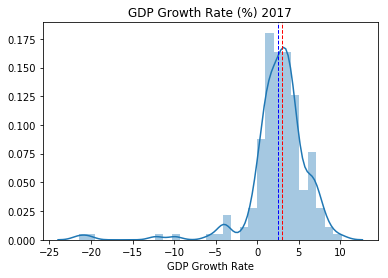

```python
# plot the variable "GDP Growth Rate" in histogram and box
meanGDP=index_2017['GDP Growth Rate'].mean()
mdGDP=index_2017['GDP Growth Rate'].median()

sns.distplot(index_2017['GDP Growth Rate'].dropna())
plt.title('GDP Growth Rate (%) 2017')
plt.axvline(meanGDP, color='b', linestyle='dashed', linewidth=1,label='mean')
plt.axvline(mdGDP, color='r', linestyle='dashed', linewidth=1,label='median')
plt.show()
```

```python
index_2017["GDP Growth Rate"].skew()
```

```
-3.000817784731934
```

```python
index_2017["GDP Growth Rate"].kurt()
```

```
15.555836893646962
```

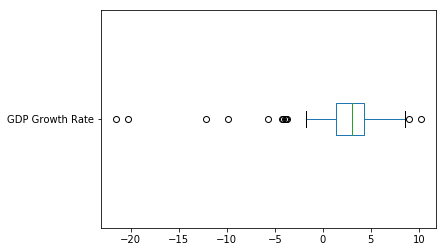

```python
plot,dataIndex=index_2017['GDP Growth Rate'].plot.box(vert=False,return_type='both')
plt.show()
```

### 2. Inflation

The mean of inflation rate in 2017 was 4.12% with a standard deviation of 10.42%. Venezuela had the largest inflation rate of 121.7%, while Lebanon's currency deflated by 3.7%. The first, second, and third quartiles of inflation rate were respectively 0.10%, 1.90%, and 5.15%.

```python
#explore the second variable: Inflation percentage
index_2017["Inflation Perc"].describe()
```

```
count    179.000000
mean       4.120670
std       10.415706
min       -3.700000
25%        0.100000
50%        1.900000
75%        5.150000
max      121.700000
Name: Inflation Perc, dtype: float64
```

Different from GDP growth rate, inflation rate was heavily skedwed to the right in the histogram and boxplot. It had a skewness of 8.72 and kurtness of 93.50. The largest and second largest inflation rates at 121.7% and 48.7% would be the two outliers that caused the right-skewed distribution.

```python
index_2017["Inflation Perc"].skew()
```

```
8.71842025902743
```

```python
index_2017["Inflation Perc"].kurt()
```

```
93.49635089140416
```

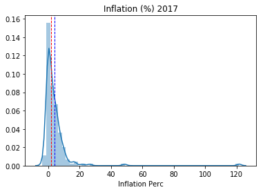

```python
# plot the variable "Inflacton Percentage" in histogram and box
meanInf=index_2017['Inflation Perc'].mean()
mdInf=index_2017['Inflation Perc'].median()

sns.distplot(index_2017['Inflation Perc'].dropna())
plt.title('Inflation (%) 2017')
plt.axvline(meanInf, color='b', linestyle='dashed', linewidth=1,label='mean')
plt.axvline(mdInf, color='r', linestyle='dashed', linewidth=1,label='median')
plt.show()
```

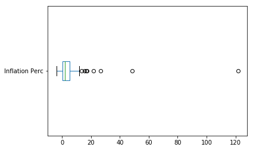

```python
plot,dataIndex=index_2017['Inflation Perc'].plot.box(vert=False,return_type='both')
plt.show()
```

### 3. Financial Freedom

Slightly belwo the median at 50, the average score of financial freedom in 2017 was 48.44 with a standard deviation of 19.10. Afghanistan was least financially free with a score of 0, while Hong Kong had the highest score of 90. Less than 25% of the countries had a score higher than 60.

```python
#explore the third variable: Financial Freedom
index_2017["Financial Freedom"].describe()
```

```
count    179.000000
mean      48.435754
std       19.103799
min        0.000000
25%       30.000000
50%       50.000000
75%       60.000000
max       90.000000
Name: Financial Freedom, dtype: float64
```

Financial freedom was alomost normally distributed without outliers. It had a skewness of -0.08 and a kurtness of -0.54.

```python
index_2017["Financial Freedom"].skew()
```

```
-0.08186839894280974
```

```python
index_2017["Financial Freedom"].kurt()
```

```
-0.5368056710232287
```

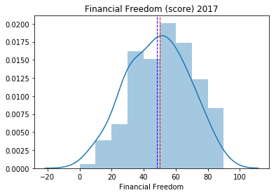

```python
# plot the variable "Financial Freedom" in histogram and box
meanfr=index_2017['Financial Freedom'].mean()
mdfr=index_2017['Financial Freedom'].median()

sns.distplot(index_2017['Financial Freedom'].dropna())
plt.title('Financial Freedom (score) 2017')
plt.axvline(meanfr, color='b', linestyle='dashed', linewidth=1,label='mean')
plt.axvline(mdfr, color='r', linestyle='dashed', linewidth=1,label='median')
plt.show()
```

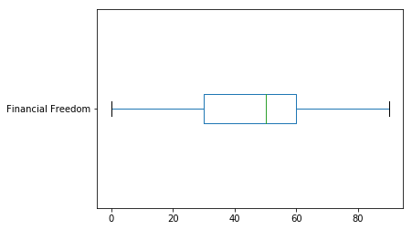

```python
plot,dataIndex=index_2017['Financial Freedom'].plot.box(vert=False,return_type='both')
plt.show()
```

## Statistical Analysis

The table below demonstrates the correlation between two of the three measurements. GDP growth rate and inflation were negatively correlated, but the correlation was not highly significant. Inflation percentage and financial freedom also had a negative correlation. GDP growth rate and financial freedom score were almost not correlated.

```python
# check out the correlation among the three variables
columns=['GDP Growth Rate', 'Inflation Perc','Financial Freedom']
indexin2017=pd.DataFrame(index_2017,columns=columns)
indexin2017.corr()
```

|  | GDP Growth Rate | Inflation Perc | Financial Freedom |
| --- | --- | --- | --- |
| GDP Growth Rate | 1.000000 | -0.246876 | 0.008955 |
| Inflation Perc | -0.246876 | 1.000000 | -0.285988 |
| Financial Freedom | 0.008955 | -0.285988 | 1.000000 |

## Geospacial Analysis

```python
# load package needed for map visualization
import geopandas as gpd
```

```python
# import and read map file
Map='https://github.com/TerriGu/data/raw/master/ne_110m_admin_0_countries.zip'
```

```python
WorldMap = gpd.GeoDataFrame.from_file(Map)
```

```python
#merge!!!
WM=WorldMap.merge(index_2017, left_on='SOVEREIGNT', right_on='Country Name')
```

```python
#before merge, how many rows do I have?
WorldMap.shape[0]
```

```
177
```

```python
#after merge, how many rows do I have?
WM.shape[0]
#and I know I'll be missing 26 countries (177-151)
```

```
151
```

### 1. GDP Growth Rate

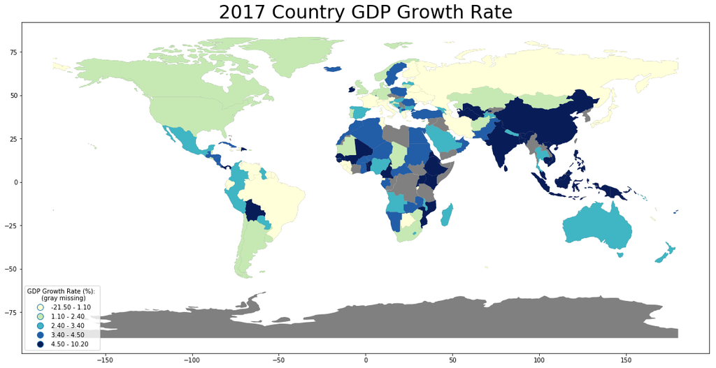

```python
import matplotlib.pyplot as plt

base = WorldMap.plot(color='gray',figsize=(20,13))

topLayer=WM.plot(ax=base,column='GDP Growth Rate',cmap='YlGnBu',scheme='Quantiles',k=5,legend=True,
                  legend_kwds={'loc': 3,'title':'GDP Growth Rate (%): \n (gray missing)'})
topLayer.set_title('2017 Country GDP Growth Rate',
                   color='black',fontdict={'fontsize':30})
leg = topLayer.get_legend()
plt.setp(leg.get_title(), multialignment='center')
plt.show()
```

### 2. Inflation

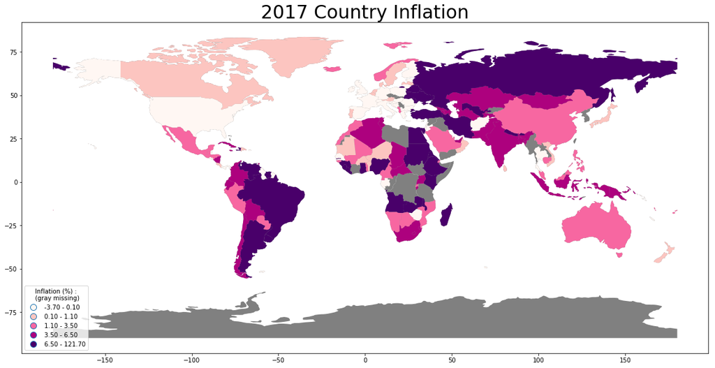

```python
base = WorldMap.plot(color='gray',figsize=(20,13))

topLayer=WM.plot(ax=base,column='Inflation Perc',cmap='RdPu',scheme='Quantiles',k=5,legend=True,
                  legend_kwds={'loc': 3,'title':'Inflation (%) : \n (gray missing)'})
topLayer.set_title('2017 Country Inflation',
                   color='black',fontdict={'fontsize':30})
leg = topLayer.get_legend()
plt.setp(leg.get_title(), multialignment='center')
plt.show()
```

### 3. Financial Freedom

Developed countries generally performed better than developing countries in terms of financial freedom. The highest scores appeared in Australia, North America, and Europe. Most Asian, African, and South American countries had a score lower than 50.

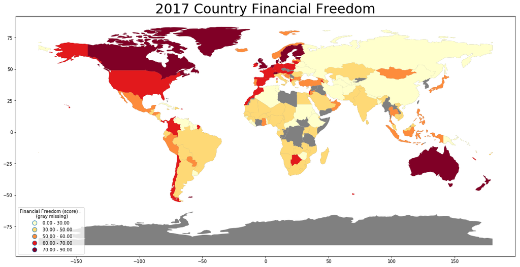

```python
base = WorldMap.plot(color='gray',figsize=(20,13))

topLayer=WM.plot(ax=base,column='Financial Freedom',cmap='YlOrRd',scheme='Quantiles',k=5,legend=True,
                  legend_kwds={'loc': 3,'title':'Financial Freedom (score) : \n (gray missing)'})
topLayer.set_title('2017 Country Financial Freedom',
                   color='black',fontdict={'fontsize':30})
leg = topLayer.get_legend()
plt.setp(leg.get_title(), multialignment='center')
plt.show()
```